# Parking garage occupancy

An exploration in Linear Models

Authors

Margarida Reis, nº99425

Mariana Galego, nº106967

Rodrigo Conceição, nº100261

Published

December 27, 2024

# 1 Introduction

The goal is to predict the occupancy of a large commercial facility’s parking garage by delineating probabilistic models that establish mathematical relationships between some statistical variables. This report outlines this problem and proposes potential solutions.  
We start by analysing our data and possible relationships with the response variable. In the context of this course, we first focus on linear models and their analysis, which includes identifying issues possibly related to the assumptions of these models and proposing possible solutions.  
Additionally, we analysed some non linear models that allowed us to score better in the competition. Alongside the construction of the models, we provide a brief overview of the theory behind them and present our conclusions. Finally, we present our Kaggle Scores and conclude which of our models predicts better the behavior of the response variable.

# 2 Description of the data

We start by loading the data to perform a exploratory data analysis, where our aim is to summarize the variables and their key characteristics to give a clear understanding of the data set.

```r
train <- read.csv("train.csv")
test <- read.csv("test.csv")
```

```r
str(train)
```

```
'data.frame':   17664 obs. of  18 variables:
 $ Year   : int  2004 2004 2004 2004 2004 2004 2004 2004 2004 2004 ...
 $ Month  : int  1 1 1 1 1 1 1 1 1 1 ...
 $ Day    : int  1 1 1 1 1 1 1 1 1 1 ...
 $ Day.w  : chr  "Th" "Th" "Th" "Th" ...
 $ is.hday: chr  "Y" "Y" "Y" "Y" ...
 $ Hour   : int  1 2 3 4 5 6 7 8 9 10 ...
 $ Tmean  : num  13.9 13.9 13.9 13.9 13.9 13.9 13.9 13.9 13.9 13.9 ...
 $ Tmax   : num  16.5 16.5 16.5 16.5 16.5 16.5 16.5 16.5 16.5 16.5 ...
 $ Tmin   : num  12.5 12.5 12.5 12.5 12.5 12.5 12.5 12.5 12.5 12.5 ...
 $ Tminr  : num  11.7 11.7 11.7 11.7 11.7 11.7 11.7 11.7 11.7 11.7 ...
 $ Rt     : num  0 0 0 0 0 0 0 0 0 0 ...
 $ Rmaxh  : num  0 0 0 0 0 0 0 0 0 0 ...
 $ Es     : int  0 0 0 0 0 0 0 0 0 0 ...
 $ Eva    : num  1 1 1 1 1 1 1 1 1 1 ...
 $ Inso   : num  0.6 0.6 0.6 0.6 0.6 0.6 0.6 0.6 0.6 0.6 ...
 $ Ev.neg : int  0 0 0 0 0 0 0 0 0 0 ...
 $ Ev.pos : int  0 0 0 0 0 0 0 0 0 0 ...
 $ y      : int  180 185 187 187 109 109 111 117 112 112 ...
```

As we have different types of variables, we use different approaches to get descriptive statistics and visualization of the data:

```r
#Continuous variables and the response variable
train %>%
  select(Tmean, Tmax, Tmin, Tminr, Rt, Rmaxh, Eva, Inso, y) %>%
  summary()
```

```
     Tmean            Tmax            Tmin           Tminr
 Min.   : 5.40   Min.   : 7.90   Min.   : 0.70   Min.   :-0.800
 1st Qu.:13.20   1st Qu.:16.50   1st Qu.:10.10   1st Qu.: 7.875
 Median :17.20   Median :21.10   Median :14.10   Median :12.200
 Mean   :17.23   Mean   :21.47   Mean   :13.73   Mean   :11.509
 3rd Qu.:21.40   3rd Qu.:26.12   3rd Qu.:17.50   3rd Qu.:15.400
 Max.   :30.90   Max.   :38.20   Max.   :26.20   Max.   :20.800
       Rt             Rmaxh              Eva              Inso
 Min.   : 0.000   Min.   : 0.0000   Min.   : 0.000   Min.   : 0.00
 1st Qu.: 0.000   1st Qu.: 0.0000   1st Qu.: 1.500   1st Qu.: 5.60
 Median : 0.000   Median : 0.0000   Median : 2.700   Median : 8.90
 Mean   : 1.759   Mean   : 0.7236   Mean   : 3.324   Mean   : 8.24
 3rd Qu.: 0.000   3rd Qu.: 0.0000   3rd Qu.: 4.500   3rd Qu.:11.50
 Max.   :73.100   Max.   :19.6000   Max.   :17.800   Max.   :13.70
       y
 Min.   :    0
 1st Qu.:  269
 Median : 1790
 Mean   : 2025
 3rd Qu.: 3226
 Max.   :11548
```

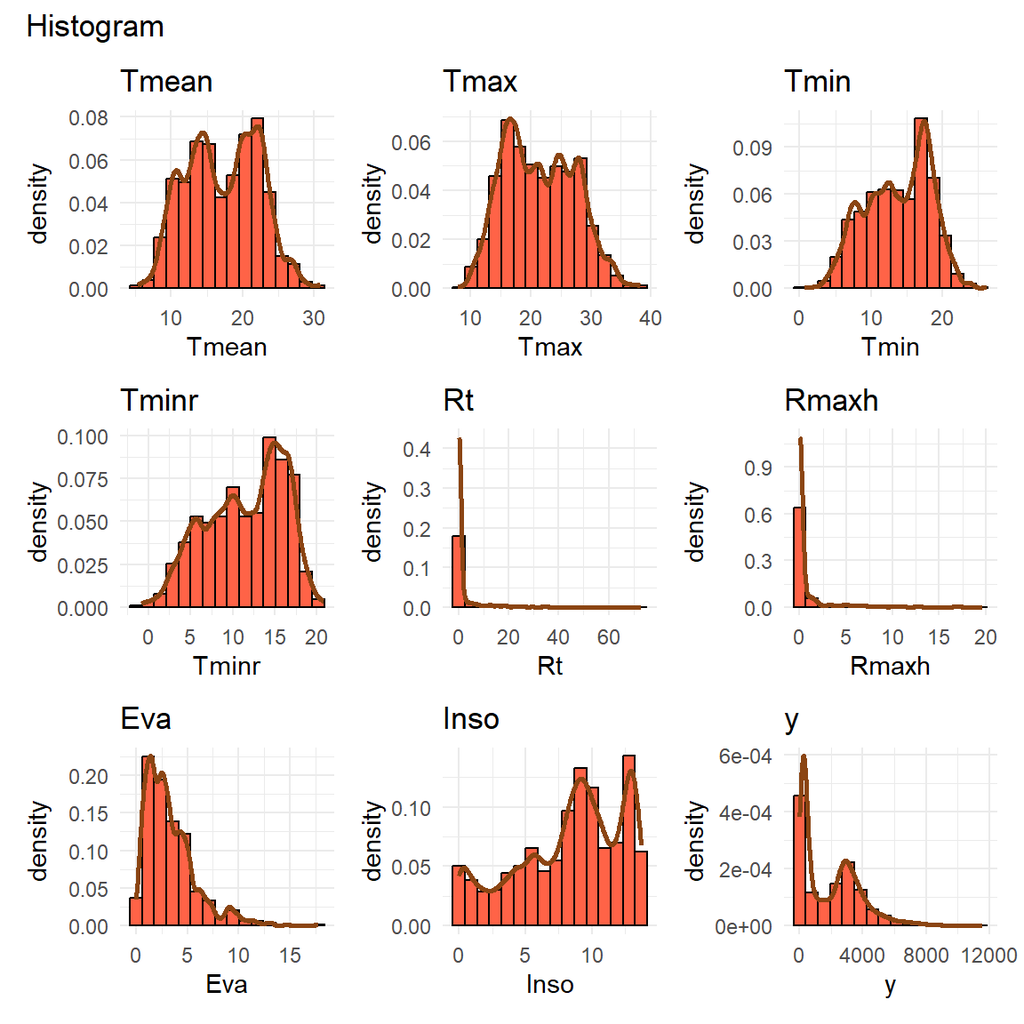

```r
plots_c<-lapply(c("Tmean","Tmax","Tmin","Tminr","Rt","Rmaxh","Eva","Inso","y"), function(i){
  classes <- ceiling(1 + log2(nrow(train)))
  ggplot(train, aes_string(x=i))+
    geom_histogram(aes(y=..density..), bins = classes, color="black", fill="tomato")+
    geom_density(color="chocolate4", size=1)+
    ggtitle(i)
})
patchwork::wrap_plots(plots_c,ncol = 3)+patchwork::plot_annotation(title = "Histogram")
```

The histograms provide valuable insights into the distributions of the variables and help us determine whether any transformations might be necessary.  
`Tmean` and `Tmax` appear to approximate a normal distribution, although there are slight irregularities in their shapes. While `Tmean` shows a noticeable dip in the center, `Tmax` exhibits a more pronounced central peak.  
Both `Tmin` and `Tminr` are slightly skewed to the left, indicating that a larger proportion of the observations are concentrated on the higher values. `Rt`, `Rmaxh` and `Eva` all display significant right skewness, with long tails of infrequent larger values, which suggests the presence of rare events.  
The `Inso` variable shows a relatively uniform distribution compared to the others, but it still has more observations on the end.  
Finally, the response variable `y` appears to have a bimodal distribution, with one very tall spike and another smaller one, followed by a heavy right tail. This could indicate distinct groups in the data or specific behaviors influencing parked cars.

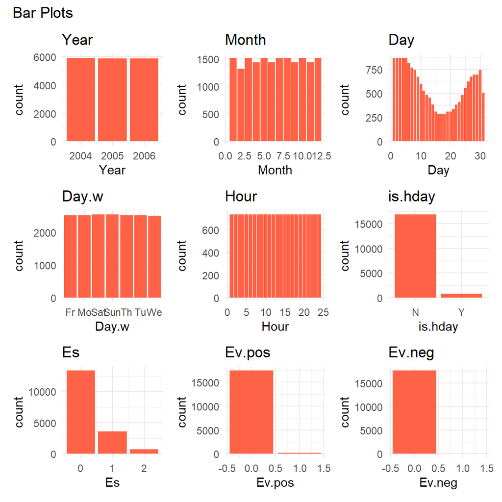

```r
#categorical or integer variables
plots_d<-lapply(c("Year","Month","Day","Day.w","Hour","is.hday","Es","Ev.pos","Ev.neg"), function(i){
  ggplot(train)+
  geom_bar(aes_string(x=i), fill="tomato")+
  ggtitle(i)
})
patchwork::wrap_plots(plots_d,ncol = 3)+patchwork::plot_annotation(title = "Bar Plots")
```

Another important aspect to analyze includes identifying outliers, as they can adversely affect model performance. Additionally, we should compute a correlation matrix to assess potential multicollinearity and examine the relationships between the response variable and each of the covariates.

```r
#to compute a correlation matrix or scatter plots we need numerical variables
train$is.hday<- as.numeric(factor(train$is.hday))
train$Day.w <- as.numeric(factor(train$Day.w, levels = c('Mo','Tu','We','Th','Fr','Sat','Sun')))
```

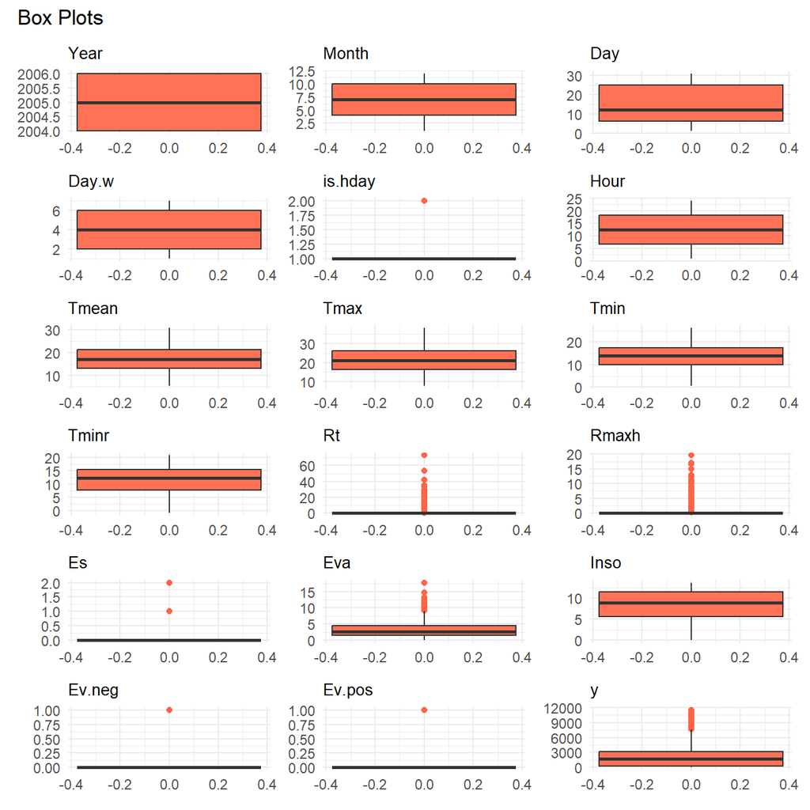

```r
plots_b<-lapply(colnames(train)[1:length(colnames(train))], function(i){
  ggplot(train)+
    geom_boxplot(aes_string(y=i), outlier.color="tomato", fill="coral1")+
    ggtitle(i)+
    labs(y=NULL)+
    theme(plot.title = element_text(size = 10))
})
patchwork::wrap_plots(plots_b,ncol = 3,nrow = 6)+patchwork::plot_annotation(title = "Box Plots")
```

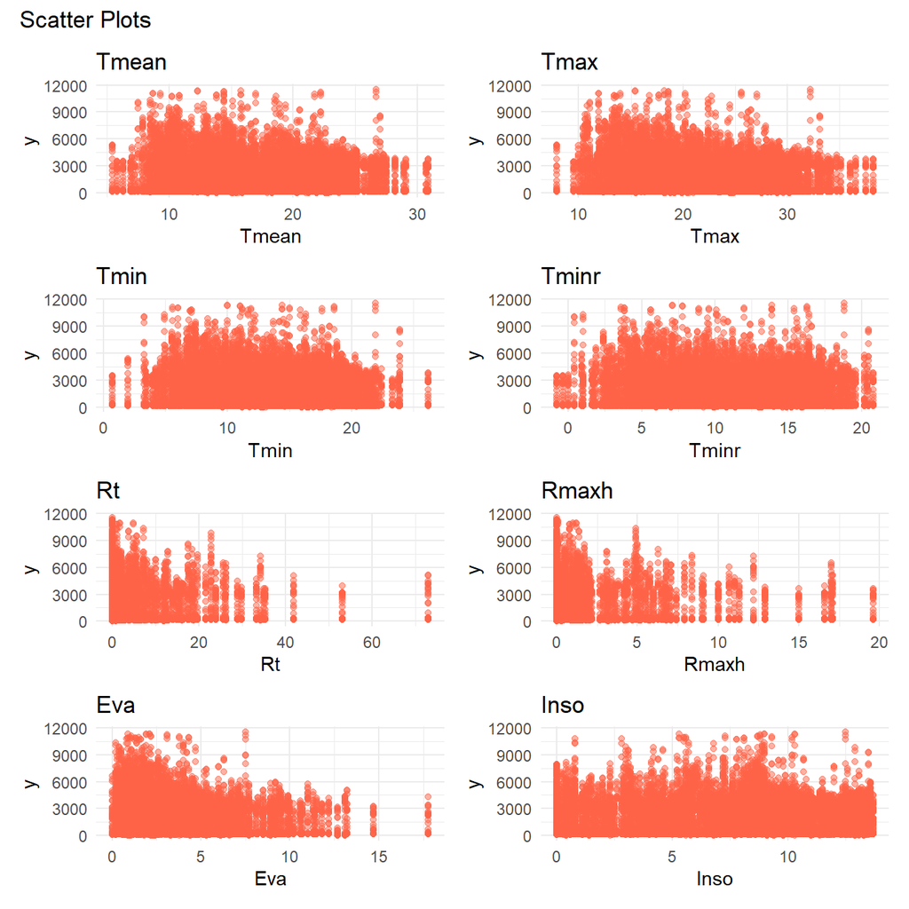

```r
plots_s<-lapply(c("Tmean","Tmax","Tmin","Tminr","Rt","Rmaxh","Eva","Inso"), function(i){
  ggplot(train)+
    geom_point(aes_string(y=colnames(train)[length(colnames(train))],x=i), color="tomato", alpha=0.5)+
    ggtitle(i)
})
patchwork::wrap_plots(plots_s,ncol = 2,nrow = 4)+patchwork::plot_annotation(title = "Scatter Plots")
```

We fit scatter plots for continuous variables to assess possible relationships between them and the response variable. None of the variables exhibit a clear linear relationship with `y`. For `Tmean`, `Tmax`, `Tmin` and `Tminr` there is a clustering of higher `y` values in the middle range of temperatures. This suggests that a quadratic transformation might better capture the potential effect of temperature on parking occupancy. On `Rt` and `Rmaxh` we see higher values associated with lower `y` values and `Eva` shows a similar distribution although not so prominent. On the first two cases a logarithmic transformation could potentially normalize their impact on `y`. Finally, `Inso` does not show a strong correlation with the response variable as the values are distributed uniformly across the range of `Inso`.

To end our analysis, we constructed a correlation matrix to examine the relationships between the covariates and the response variable, `y`, as well as to identify any potential issues related to multicollinearity.  
The correlation matrix reveals that `Hour` exhibits a strong correlation with `y`, indicating that it may play a significant role in predicting parking garage occupancy. Additionally, we observe that the temperature-related variables—`Tmin`, `Tminr`, `Tmean`, and `Tmax`—are highly correlated with each other. This strong correlation between these covariates suggests the potential for multicollinearity, which could affect the stability and interpretability of the model coefficients when fitting predictive models.

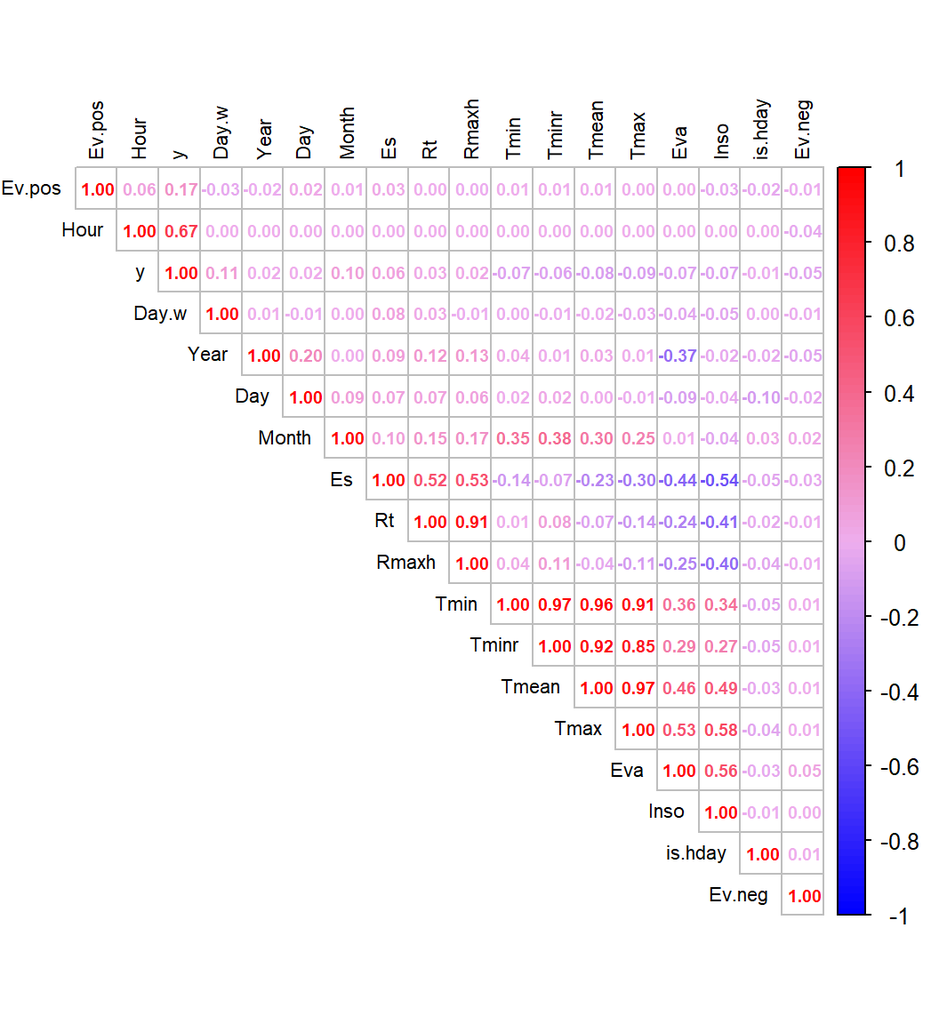

```r
corrmatrix = cor(train)

corrplot::corrplot(corrmatrix, type = "upper", order = "hclust",tl.col = "black", method = "number",tl.cex = 0.7, number.cex = 0.6, col = colorRampPalette(c("blue","plum2", "red" ))(100))
```

# 3 Methods

We know present several models that we fitted during the competition. In the context of this course, we also provide possible and simple solutions aimed at validating our linear model. So we highlight that most of the linear models were built with the academic goal of better meeting the assumptions, rather than improving predictive power. Most likely, as we increase the complexity of our models by adding covariates or adjusting the weights of observations we are increasing the risk of overfitting.

## 3.1 Linear Model

In accordance with the principle of parsimony, we aim to choose the simplest model that explains our data. In this context, this means starting with the simplest and most well-understood model: linear regression model. Given we have multiple covariates we must consider its generalized form.  
The general linear model in matrix form is given by $\mathbf{y} = \mathbf{X}\mathbf{\beta} + \mathbf{e}$, where $\mathbf{y}$ is a vector of observations of the response variable; $\mathbf{X}$ is the design matrix, which contains values of covariates ; $\mathbf{\beta}$ is the vector of parameters and $\mathbf{e}$ is the vector of random components with $\mathbf{e} \sim N_n(\mathbf{0},\sigma^2\mathbf{I})$.  
For a linear model to be valid and its theoretical interpretations reliable it has to meet some assumptions:

- The relationship between the response variable and the covariates must be linear
- The residuals must be uncorrelated and follow a normal distribution with constant variance

In addition to this assumptions, linear models may encounter other problems that can affect their performance and interpretability such as:

- Outliers and Leverage points: This observations can have an excessive influence on the model, distorting estimates of regression coefficients and potentially compromising the model’s predictive performance.
- Multicollinearity: This is a large correlation between covariates, that can inflate standard errors, making it difficult to determine the individual effect of each predictor and potentially reducing the reliability of the model’s estimates.

We begin by proposing a candidate linear model through the selection of covariates from our dataset. This initial model serves as the foundation for further refinement and analysis. The following table summarizes key metrics used for model comparison across different subsets of predictors and highlights the model with best predictive power based on cross validation:

```r
bestsubsets<-regsubsets(y~.,data=train,nvmax = 17)
regsum<-summary(bestsubsets)
```

```r
metrics<- data.frame(P = 2:18, adjR2 = regsum$adjr2, BIC = regsum$bic, Cp_p = abs(regsum$cp - 2:18))
metrics %>%
  kableExtra::kbl(format = "html", align = "c") %>%
  kableExtra::row_spec(which(metrics$P==12), bold = TRUE, background = "lightsalmon")
```

Table 1: Summary of Model Comparison Metrics

| P | adjR2 | BIC | Cp_p |
| --- | --- | --- | --- |
| 2 | 0.4476578 | -10466.57 | 1986.2633261 |
| 3 | 0.4649898 | -11020.96 | 1369.6386652 |
| 4 | 0.4784717 | -11463.00 | 890.0314292 |
| 5 | 0.4888351 | -11808.76 | 521.3881160 |
| 6 | 0.5014365 | -12240.90 | 73.1959738 |
| 7 | 0.5021760 | -12258.34 | 46.8953483 |
| 8 | 0.5025453 | -12262.67 | 33.7591461 |
| 9 | 0.5028727 | -12265.52 | 22.1137289 |
| 10 | 0.5030902 | -12264.47 | 14.3783199 |
| 11 | 0.5032457 | -12261.22 | 8.8503196 |
| 12 | 0.5034827 | -12260.87 | 0.4241425 |
| 13 | 0.5035280 | -12253.71 | 1.1882574 |
| 14 | 0.5035466 | -12245.59 | 1.8472692 |
| 15 | 0.5035418 | -12236.64 | 1.6770692 |
| 16 | 0.5035266 | -12227.32 | 1.1350202 |
| 17 | 0.5035115 | -12218.00 | 0.6005858 |
| 18 | 0.5034946 | -12208.63 | 0.0000000 |

- $\b{R^2_a}$: Adjusted R-squared tells us how well a set of predictor variables is able to explain the variation in the response variable, adjusted for the number of predictors in a model. Because of the way it’s calculated, adjusted R-squared can be used to compare the fit of regression models with different numbers of predictor variables.
- **BIC**: The Bayesian Information Criterion is a measure of model fit that also incorporates a penalty for the number of parameters in the model. The BIC helps prevent overfitting by discouraging the inclusion of unnecessary predictors. A lower BIC indicates a better-fitting model when balancing fit and complexity.
- **Cp_p**: Mallow’s Cp is a model selection criterion that compares the residual sum of squares, RSS, of a model with the number of predictors. Cp_p measures how close the Mallow’s Cp value is to the number of predictors. Ideally, Mallow’s Cp should be close to the number of predictors p, indicating a well-balanced model.

```r
f <- as.formula(paste("y ~", paste(names(coef(bestsubsets, which.min(cv.errors)))[-1], collapse = " + ")))
mod_l <- lm(f, data = train)
summary(mod_l)
```

```
Call:
lm(formula = f, data = train)

Residuals:
    Min      1Q  Median      3Q     Max
-5730.1  -702.5   -77.0   584.3  7999.2

Coefficients:
             Estimate Std. Error t value Pr(>|t|)
(Intercept)  -238.990     73.198  -3.265 0.001097 **
Month          75.059      3.177  23.623  < 2e-16 ***
Day.w         104.421      4.986  20.941  < 2e-16 ***
is.hday      -154.827     48.942  -3.163 0.001562 **
Hour          178.826      1.440 124.151  < 2e-16 ***
Tmax          -39.237      5.789  -6.778 1.26e-11 ***
Tmin           42.007     12.875   3.263 0.001106 **
Tminr         -44.638     10.246  -4.357 1.33e-05 ***
Eva           -18.933      5.180  -3.655 0.000258 ***
Inso           12.105      3.863   3.134 0.001729 **
Ev.neg      -1007.950    200.118  -5.037 4.78e-07 ***
Ev.pos       2508.669     99.108  25.313  < 2e-16 ***
---
Signif. codes:  0 '***' 0.001 '**' 0.01 '*' 0.05 '.' 0.1 ' ' 1

Residual standard error: 1322 on 17652 degrees of freedom
Multiple R-squared:  0.5038,    Adjusted R-squared:  0.5035
F-statistic:  1629 on 11 and 17652 DF,  p-value: < 2.2e-16
```

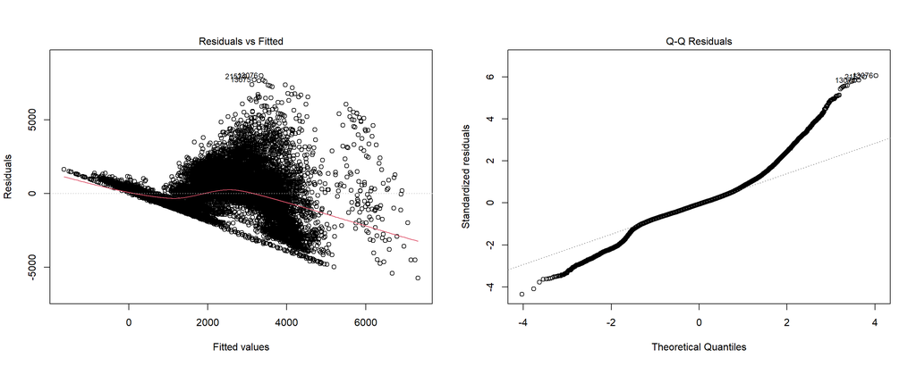

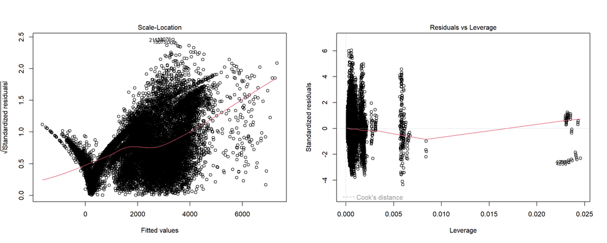

```r
par(mfrow=c(1,2))
plot(mod_l)
```

```r
lmtest::dwtest(mod_l)
```

```
    Durbin-Watson test

data:  mod_l
DW = 0.53322, p-value < 2.2e-16
alternative hypothesis: true autocorrelation is greater than 0
```

Although the model with 11 predictors was not optimal for any single metric in Table 1, because it did not have the highest Adjusted $R^2$, lowest BIC, or closest Cp value to the number of predictors, cross-validation revealed that it exhibited the best predictive performance on unseen data. This highlights the importance of balancing model fit with generalization, as metrics like Adjusted $R^2$ or BIC do not necessarily predict how well a model will perform on new, unseen data.

```r
car::vif(mod_l)
```

```
    Month     Day.w   is.hday      Hour      Tmax      Tmin     Tminr       Eva
 1.213092  1.008305  1.007189  1.005132 11.677323 34.744957 22.667754  1.665947
     Inso    Ev.neg    Ev.pos
 2.274892  1.006074  1.007186
```

Recalling the exploratory analysis we conducted earlier, we are aware that the model that we fit based on the `regsubset` and cross validation exhibits multicollinearity. To further investigate this issue, we use another metric, VIF, Variance Inflation Factor, which estimates how much the variance of a regression coefficient is inflated due to multicollinearity.  
However, this metric should be used with caution, as a high VIF doesn’t always indicate a problem with the coefficients. For example, the inclusion of products or powers of others variables will increase the VIFs without necessairly causing negative impacts.  
Based on the correlation matrix and the rule of thumb that a VIF greater than 10 indicates a significant problem, we identified that the major problem lies with the set of covariates `Tmax`, `Tmin` and `Tminr`. To address this, we remove the covariate `Tminr`, which led to decrease in the VIFs without any significant changes in the diagnostic plots.

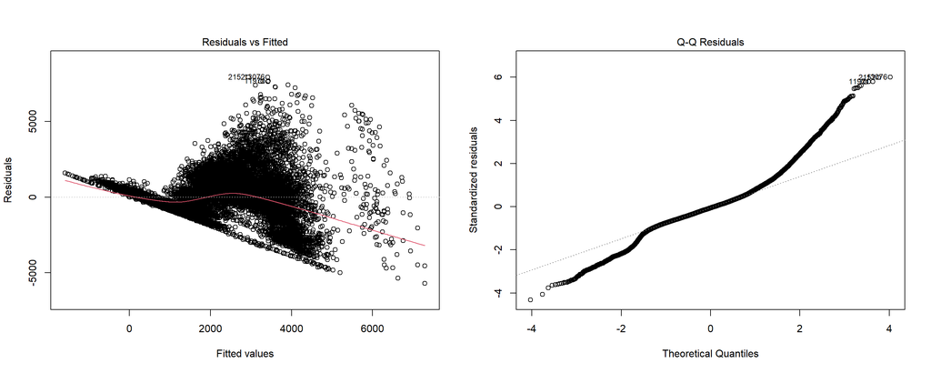

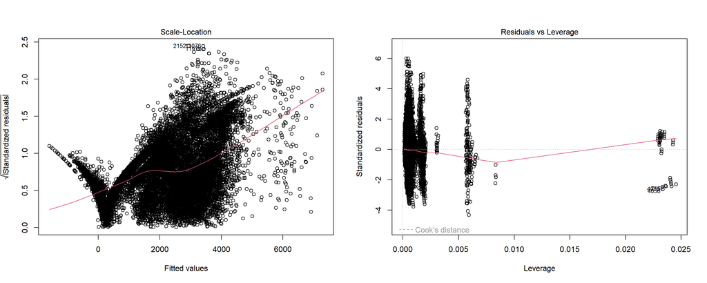

```r
f1 <- update(f, paste(". ~ . -", "Tminr"))
mod_l1 <- lm(f1, data = train)
par(mfrow=c(1,2))
plot(mod_l1)
```

```r
car::vif(mod_l1)
```

```
    Month     Day.w   is.hday      Hour      Tmax      Tmin       Eva      Inso
 1.184511  1.005236  1.006540  1.005132 11.418061  8.504203  1.655236  2.254347
   Ev.neg    Ev.pos
 1.005953  1.007051
```

Diagnostic plots are essential tools for evaluating the validity of a linear regression. They help assess whether the key assumptions underlying the model are satisfied. The plots for our first model indicate that there exists some problems and the assumptions underlying the validity of a linear regression model are not fully met. Consequently, we cannot rely on the p-values or other metrics presented in the `summary(mod_l1)` output to draw meaningful conclusions.  
The Residuals vs Fitted plot shows clear patterns, indicating a non linear relationship between the covariates and the response variable. The residuals are not randomly scattered around the zero line which also exhibits curves, further suggesting that the linearity assumption is violated.  
From the Scale-Location plot it’s evident that the variance of the residuals is not constant across fitted values. The red line slopes upward and the points show a pattern resembling a “V” shape, which clearly indicates heteroscedasticity.  
The Durbin-Watson test was applied to check for first-order autocorrelation in the residuals. The null hypothesis of no autocorrelation was reject, indicating that the residuals are correlated. The QQ plot revels that the residuals deviate substantially from the theoretical normal distribution, particularly in the tails.  
The Residuals vs Leverage plot highlights several points with high leverage. However, none of these points surpass the Cook’s distance threshold, indicating that while they may be influential in terms of leverage, they do not exhibit a significant influence on the regression model based on Cook’s distance.

Now that we have identified the issues that undermine our model, we can explore potential solutions to better meet the underlying assumptions.  
The first step was addressing the non linearity issue. One approach to resolving this is by adding polynomials terms, interactions or transformations taking into account our exploratory analysis.  
Since our response variable contains zeros, we were unable to use the `Box-Cox` function to determine the best transformation. Instead, we tried common transformations, such as square root and log transformations.

```r
#to capture the cyclic pattern of Hour and Month
train$sin_hour <- sin(2 * pi * train$Hour / 24)
train$cos_hour <- cos(2 * pi * train$Hour / 24)
train$sin_month <- sin(2 * pi * train$Month / 12)
train$cos_month <- cos(2 * pi * train$Month / 12)
```

```r
f_sqrt<-sqrt(y)~Month+Day.w+is.hday+Hour+Tmax+I(Tmax^2)+Tmin+I(Tmin^2)+I(log1p(Eva))+Inso+Ev.neg+Ev.pos+Month:is.hday+Day.w:Hour+cos_hour+sin_hour+Tmax:Hour+Ev.pos:Tmax+Ev.neg:Day.w+cos_month+sin_month
mod_sqrt<-lm(f_sqrt,data = train)
summary(mod_sqrt)
```

```
Call:
lm(formula = f_sqrt, data = train)

Residuals:
    Min      1Q  Median      3Q     Max
-67.238  -4.785  -0.256   4.124  45.715

Coefficients:
                Estimate Std. Error  t value Pr(>|t|)
(Intercept)    44.634670   1.470603   30.351  < 2e-16 ***
Month          -0.434444   0.098203   -4.424 9.75e-06 ***
Day.w           0.414883   0.068862    6.025 1.73e-09 ***
is.hday       -11.298334   0.680381  -16.606  < 2e-16 ***
Hour            0.781588   0.043423   18.000  < 2e-16 ***
Tmax           -0.564974   0.142845   -3.955 7.68e-05 ***
I(Tmax^2)       0.009291   0.002880    3.226 0.001257 **
Tmin           -0.343757   0.136601   -2.517 0.011861 *
I(Tmin^2)       0.018243   0.004757    3.835 0.000126 ***
I(log1p(Eva))  -1.141141   0.177936   -6.413 1.46e-10 ***
Inso            0.199071   0.028204    7.058 1.75e-12 ***
Ev.neg        -11.714917   2.170872   -5.396 6.89e-08 ***
Ev.pos         20.217118   2.651049    7.626 2.54e-14 ***
cos_hour       -5.005276   0.095773  -52.262  < 2e-16 ***
sin_hour      -21.985928   0.150127 -146.449  < 2e-16 ***
cos_month       0.323904   0.184449    1.756 0.079096 .
sin_month       1.280215   0.213329    6.001 2.00e-09 ***
Month:is.hday   1.114477   0.085463   13.040  < 2e-16 ***
Day.w:Hour      0.039728   0.004809    8.261  < 2e-16 ***
Hour:Tmax      -0.013563   0.001639   -8.275  < 2e-16 ***
Tmax:Ev.pos     0.186209   0.119118    1.563 0.118015
Day.w:Ev.neg   -3.010401   0.486351   -6.190 6.16e-10 ***
---
Signif. codes:  0 '***' 0.001 '**' 0.01 '*' 0.05 '.' 0.1 ' ' 1

Residual standard error: 8.826 on 17642 degrees of freedom
Multiple R-squared:  0.8379,    Adjusted R-squared:  0.8377
F-statistic:  4341 on 21 and 17642 DF,  p-value: < 2.2e-16
```

```r
f_log<-log1p(y)~Month+Day.w+is.hday+Hour+Tmax+I(Tmax^2)+Tmin+I(Tmin^2)+I(log1p(Eva))+Inso+Ev.neg+Ev.pos+Month:is.hday+Day.w:Hour+cos_hour+sin_hour+Tmax:Hour+Ev.pos:Tmax+Ev.neg:Day.w+cos_month+sin_month
mod_log<-lm(f_log,data = train)
summary(mod_log)
```

```
Call:
lm(formula = f_log, data = train)

Residuals:
    Min      1Q  Median      3Q     Max
-5.0000 -0.3192  0.0246  0.2984  1.7849

Coefficients:
                Estimate Std. Error  t value Pr(>|t|)
(Intercept)    7.152e+00  7.902e-02   90.519  < 2e-16 ***
Month         -2.949e-02  5.276e-03   -5.589 2.32e-08 ***
Day.w          2.878e-02  3.700e-03    7.778 7.75e-15 ***
is.hday       -7.180e-01  3.656e-02  -19.641  < 2e-16 ***
Hour           4.522e-02  2.333e-03   19.380  < 2e-16 ***
Tmax          -1.098e-02  7.675e-03   -1.431 0.152393
I(Tmax^2)      3.416e-05  1.547e-04    0.221 0.825296
Tmin          -2.227e-02  7.340e-03   -3.034 0.002414 **
I(Tmin^2)      8.689e-04  2.556e-04    3.399 0.000678 ***
I(log1p(Eva)) -3.703e-02  9.561e-03   -3.873 0.000108 ***
Inso           6.995e-03  1.515e-03    4.616 3.94e-06 ***
Ev.neg        -5.149e+00  1.166e-01  -44.143  < 2e-16 ***
Ev.pos         6.524e-01  1.424e-01    4.580 4.68e-06 ***
cos_hour      -3.314e-01  5.146e-03  -64.406  < 2e-16 ***
sin_hour      -1.293e+00  8.066e-03 -160.245  < 2e-16 ***
cos_month     -6.153e-03  9.911e-03   -0.621 0.534709
sin_month      5.646e-02  1.146e-02    4.926 8.49e-07 ***
Month:is.hday  5.722e-02  4.592e-03   12.461  < 2e-16 ***
Day.w:Hour     1.196e-04  2.584e-04    0.463 0.643356
Hour:Tmax      1.171e-05  8.806e-05    0.133 0.894256
Tmax:Ev.pos    1.787e-02  6.400e-03    2.792 0.005248 **
Day.w:Ev.neg  -1.964e-01  2.613e-02   -7.514 6.01e-14 ***
---
Signif. codes:  0 '***' 0.001 '**' 0.01 '*' 0.05 '.' 0.1 ' ' 1

Residual standard error: 0.4742 on 17642 degrees of freedom
Multiple R-squared:  0.8753,    Adjusted R-squared:  0.8752
F-statistic:  5899 on 21 and 17642 DF,  p-value: < 2.2e-16
```

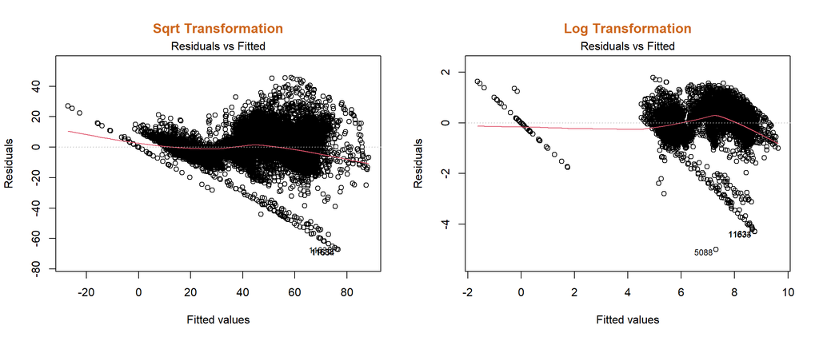

```r
par(mfrow = c(1, 2))
plot(mod_sqrt,which = 1)
title(main = "Sqrt Transformation", col.main = "chocolate3")
plot(mod_log,which = 1)
title(main = "Log Transformation", col.main = "chocolate3")
```

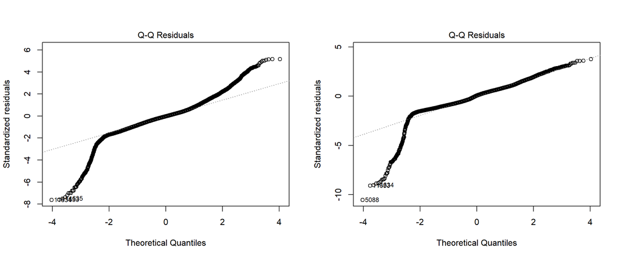

```r
plot(mod_sqrt,which = 2)
plot(mod_log,which = 2)
```

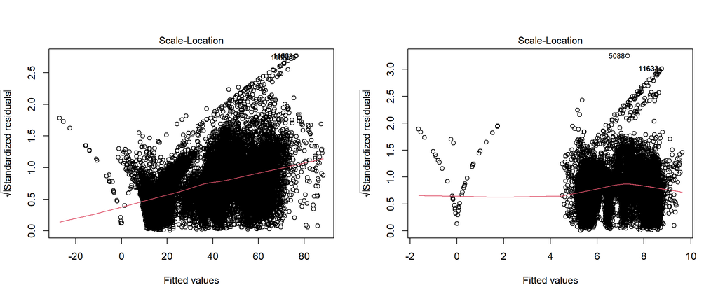

```r
plot(mod_sqrt,which = 3)
plot(mod_log,which = 3)
```

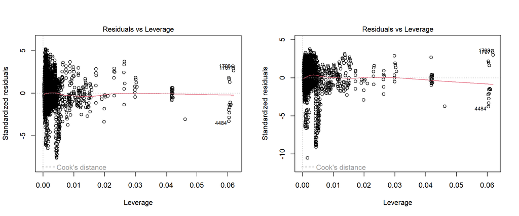

```r
plot(mod_sqrt,which = 5)
plot(mod_log,which = 5)
```

```r
lmtest::dwtest(mod_sqrt)
```

```
    Durbin-Watson test

data:  mod_sqrt
DW = 0.41325, p-value < 2.2e-16
alternative hypothesis: true autocorrelation is greater than 0
```

```r
lmtest::dwtest(mod_log)
```

```
    Durbin-Watson test

data:  mod_log
DW = 0.41314, p-value < 2.2e-16
alternative hypothesis: true autocorrelation is greater than 0
```

From the set of diagnostic plots generated for the new models, we can draw several conclusions regarding the transformations and their effectiveness in addressing the underlying issues. Both transformations, along with the added covariates, help mitigate some of the non linearity present in the data.  
The square root transformation reduces the prominence of the non linear pattern in the Residuals vs. Fitted values plot. On the case of the log transformation, the fitted values represent the transformed response variable, and the clustering observed toward the right side of the plot is a result of the transformation compressing larger values. This does not necessarily indicate that the model is worse at addressing non linearity, but rather reflects the nature of the log transformation itself. Despite this, the Residuals vs. Fitted plot for the log-transformed model still reveals an “S” shape, which suggests that the relationship between the response variable and the covariates is not fully captured by the model or the chosen transformation.

When we analyse the other plots, it appears that the log transformation addresses the non normality of the residuals more effectively, as well as smoothing the heteroscedasticity. However, both transformations fail to completely resolve the issue.

Given the presence of heteroscedasticity in both models, we next explore the use of weighted regression to mitigate this problem. In weighted regression, each observation is assigned a weight that indicates its relative importance in the model fit. In the context of heteroscedasticity, the goal is to down-weight observations with larger residuals (which typically correspond to observations with higher variance) and up-weight those with smaller residuals (which tend to have more consistent variance). This adjustment helps the model focus more on reliable observations, ultimately improving the overall model fit in the presence of heteroscedasticity.

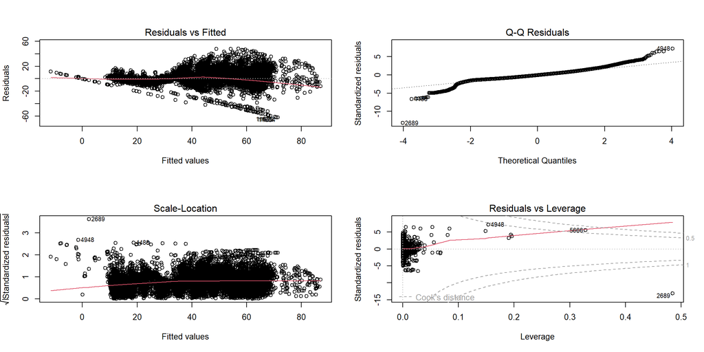

```r
w_sqrt <- 1 / lm(abs(mod_sqrt$residuals) ~ mod_sqrt$fitted.values)$fitted.values^2
mod_wsqrt<-lm(f_sqrt,data = train, weights = w_sqrt)
par(mfrow=c(2,2))
plot(mod_wsqrt)
```

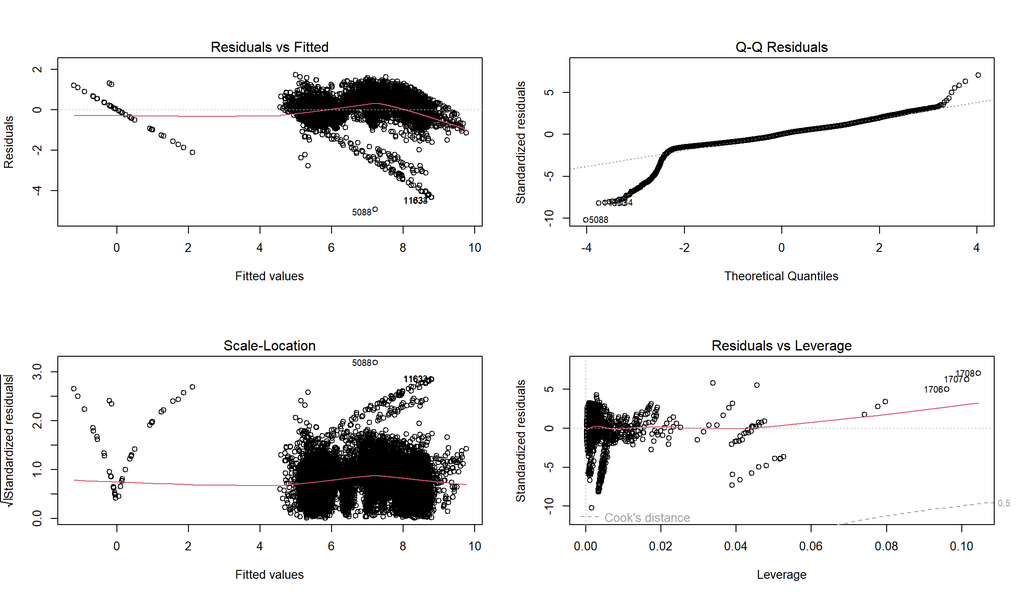

```r
w_log <- 1 / lm(abs(mod_log$residuals) ~ mod_log$fitted.values)$fitted.values^2
mod_wlog<-lm(f_log,data = train, weights = w_log)
par(mfrow=c(2,2))
plot(mod_wlog)
```

From the Scale-Location Plots, we can conclude that the weighted regression effectively addressed the heteroscedasticity problem, particularly with the square root transformation. It also improved the normality of the residuals, as both QQ plots show an improvement on the tails, with only a few observations remaining far from the expected distribution.  
However, the Residuals vs Leverage plot reveals that the outliers are now more prominent, as some observations fall outside the Cook’s distance threshold. One thing very tentative to do is just remove some of the observations that are causing us trouble using the rule of thumb for Cooks distance.

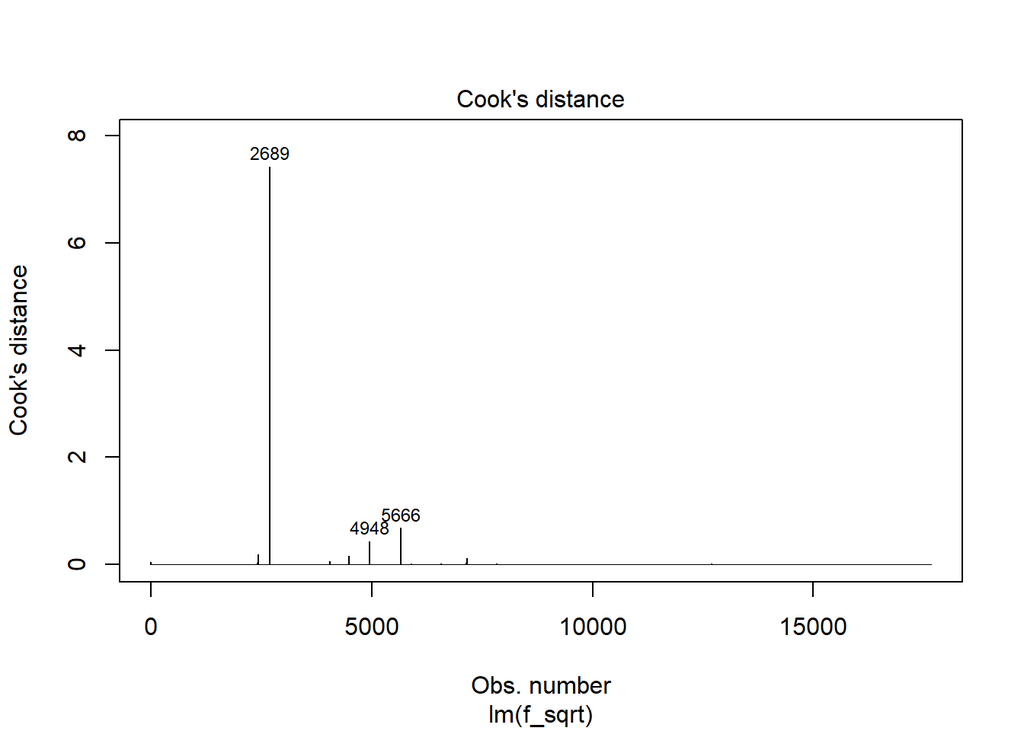

```r
plot(mod_wsqrt,which = 4)
```

```r
o_wsqrt <- which(cooks.distance(mod_wsqrt) > (4 / nrow(train)))
mod_wsqrto<-lm(f_sqrt,data = train[-o_wsqrt,], weights = w_sqrt[-o_wsqrt])
```

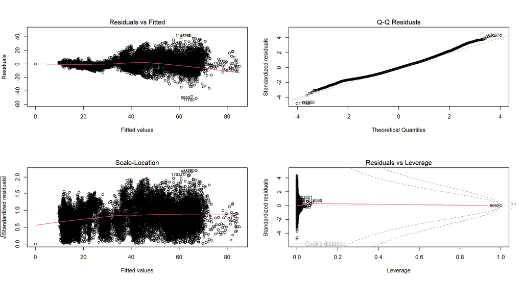

```r
par(mfrow=c(2,2))
plot(mod_wsqrto)
```

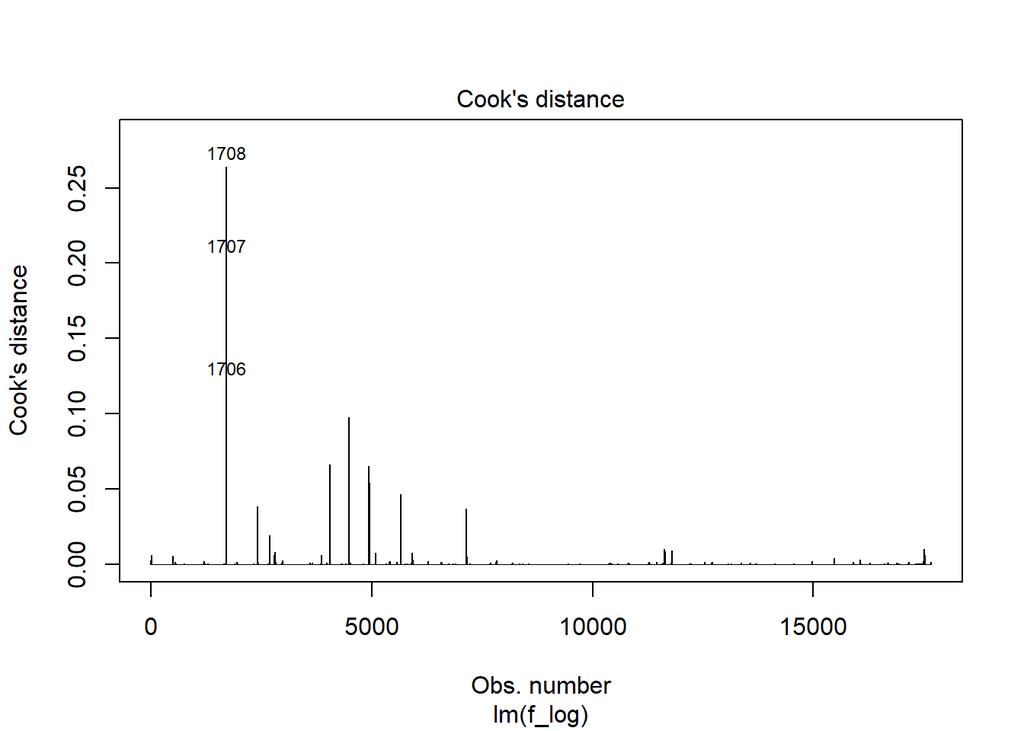

```r
plot(mod_wlog,which = 4)
```

```r
o_wlog <- which(cooks.distance(mod_wlog) > (4 / nrow(train)))
mod_wlogo<-lm(f_log,data = train[-o_wlog,], weights = w_log[-o_wlog])
```

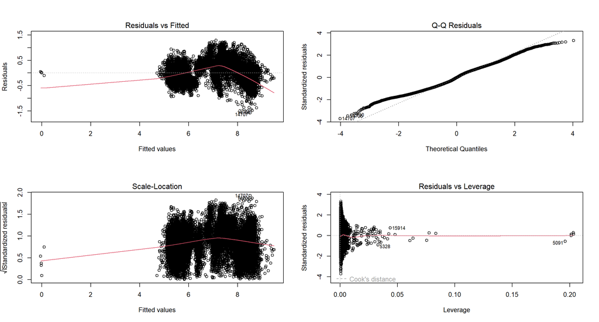

```r
par(mfrow=c(2,2))
plot(mod_wlogo)
```

```r
r_sqrt<-residuals(mod_wsqrto)
lmtest::dwtest(r_sqrt~fitted(mod_wsqrto))
```

```
    Durbin-Watson test

data:  r_sqrt ~ fitted(mod_wsqrto)
DW = 0.49127, p-value < 2.2e-16
alternative hypothesis: true autocorrelation is greater than 0
```

```r
r_log<-residuals(mod_wlogo)
lmtest::dwtest(r_log~fitted(mod_wlogo))
```

```
    Durbin-Watson test

data:  r_log ~ fitted(mod_wlogo)
DW = 0.51609, p-value < 2.2e-16
alternative hypothesis: true autocorrelation is greater than 0
```

To this end, since these data points are not data entry errors, neither they are from a different population than most of our data, we have no compelling reason to exclude them from the analysis. Instead, we need an alternative approach to handle them.  
We decided to fit a robust model, as the idea behind robust regression is to weigh the observations differently based on how well behaved they are. Unlike Weighted Least Square, which assign fixed weights based on know variances, robust regression automatically reduces the influence of outliers during the fitting process.

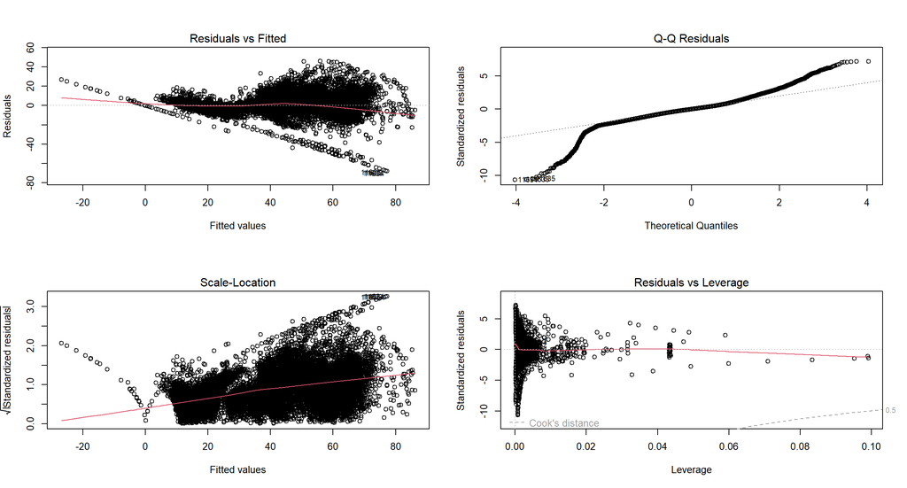

```r
mod_rsqrt<-MASS::rlm(f_sqrt,data = train)
par(mfrow=c(2,2))
plot(mod_rsqrt)
```

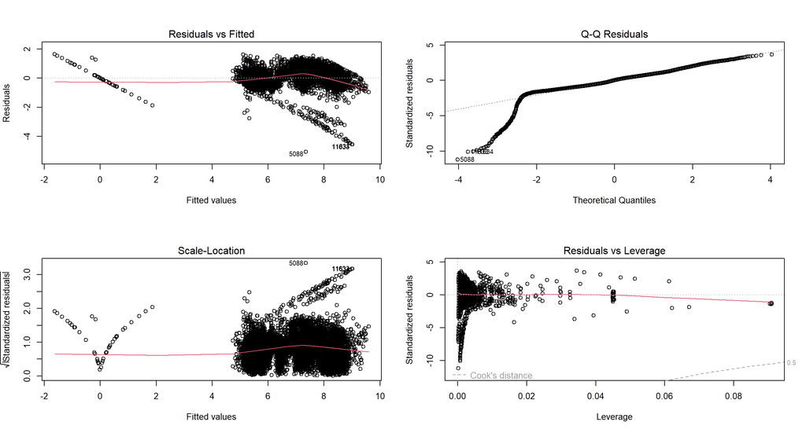

```r
mod_rlog<-MASS::rlm(f_log,data = train)
par(mfrow=c(2,2))
plot(mod_rlog)
```

```r
lmtest::dwtest(mod_rsqrt)
```

```
    Durbin-Watson test

data:  mod_rsqrt
DW = 0.41325, p-value < 2.2e-16
alternative hypothesis: true autocorrelation is greater than 0
```

```r
lmtest::dwtest(mod_rlog)
```

```
    Durbin-Watson test

data:  mod_rlog
DW = 0.41314, p-value < 2.2e-16
alternative hypothesis: true autocorrelation is greater than 0
```

The robust regression appears to have effectively addressed the outliers, especially in the case of the square root transformation. However, the solution provided by weighted regression for the heteroscedasticity was more effective than the one found in this final model.

## 3.2 Non Linear Model

Even with the transformations or added covariates, we were unable to fully mitigate the issue of non linearity. Additionally, most of our attempts to address the other assumptions did not entirely resolve the problems either.  
As a result, we moved away from our linear model and explored other models that could better capture the patterns in our data set.

### 3.2.1 Random Forests

The term “Random” refers to the algorithm’s behavior when selecting subsets of features and assembling decision trees. As multiple decision trees are generated, the term “Forest” is quite fitting.  
To understand how Random Forests work, we must first introduce decision trees, which are simpler algorithms. In this context, this type of structures are used to make predictions. They consist of nodes representing decisions or tests on attributes, branches representing the outcome of these decisions, and leaf nodes representing final outcomes or predictions. The process of creating a decision tree involves the selection of a best attribute which is used to split the data set. Then we repeat this process recursively for each subset, creating new nodes or leaf nodes until a stopping criteria is met.  
Random Forest algorithm works by generating multiple decision trees during the training phase. Each tree is built using a random subset of the data set. This randomness introduces variability among individual trees, reducing the risk of overfitting and improving overall prediction performance.  
Finally, each decision tree in the Random Forest casts its vote, and for regression tasks, the average of all individual trees predictions is taken.

```r
set.seed(1)
mod_rf <- randomForest(y ~ . , data = train[,!(names(train) %in% c("sin_hour", "cos_hour", "sin_month", "cos_month"))], importance=TRUE)
importance(mod_rf)
```

```
          %IncMSE IncNodePurity
Year     35.22531     234453915
Month    80.99492    2065406997
Day      54.17054    1039105940
Day.w   123.81036    2315362046
is.hday  46.92203     532012862
Hour    536.72630   44594738519
Tmean    35.06424     819869989
Tmax     30.41696     949931047
Tmin     33.18646     768356288
Tminr    31.00259     769869734
Rt       23.17702     385365009
Rmaxh    22.66719     303462347
Es       16.93062     177698345
Eva      36.04874     817326485
Inso     36.56521     933614483
Ev.neg   17.07675      52032854
Ev.pos   80.24073    1713693719
```

As we did in the section, we can create additional covariates or interactions to try to better capture better the behavior of the response variable

```r
newtrain<-train
newtrain$temp_holiday_interaction <- newtrain$Tmax * newtrain$is.hday
newtrain$rain_event_pos_interaction <- newtrain$Rt * newtrain$Ev.pos
newtrain$Tmax_roll_avg <- zoo::rollmean(newtrain$Tmax, k = 3,fill=newtrain$Tmax)
newtrain$Tmin_roll_avg <- zoo::rollmean(newtrain$Tmin, k = 3,fill=newtrain$Tmin)
newtrain$rain_event_neg_interaction <- newtrain$Rmaxh * newtrain$Ev.neg
```

```r
set.seed(1)
mod_rf1<-randomForest(y~., data=newtrain,ntree=1000,importance=TRUE)
```

As the dimension of our data set is large enough and because we got a good score, as we will see on Results section, we created more covariates.

```r
newtrain$time_of_day <- cut(newtrain$Hour,
                            breaks = c(0, 6, 12, 18, 24),
                            labels = c("Night", "Morning", "Afternoon", "Evening"))
newtrain$hour_day_interaction <- newtrain$Hour * newtrain$Day.w
newtrain$rain_hour_interaction <- newtrain$Rt * newtrain$Hour
newtrain$rain_event_holiday <- newtrain$Rt * newtrain$is.hday
newtrain$cumulative_evpos <- cumsum(newtrain$Ev.pos)
newtrain$cumulative_evneg <- cumsum(newtrain$Ev.neg)
newtrain$event_temp_interaction <- newtrain$Ev.pos * newtrain$Tmean
newtrain$Tmax_lag1 <- lag(newtrain$Tmax, n = 1)
newtrain$Tmax_lag1[is.na(newtrain$Tmax_lag1)] <- newtrain$Tmax[is.na(newtrain$Tmax_lag1)]
newtrain$Tmin_lag1 <- lag(newtrain$Tmin, n = 1)
newtrain$Tmin_lag1[is.na(newtrain$Tmin_lag1)] <- newtrain$Tmin[is.na(newtrain$Tmin_lag1)]
newtrain$Tmean_lag1 <- lag(newtrain$Tmean, n = 1)
newtrain$Tmean_lag1[is.na(newtrain$Tmean_lag1)] <- newtrain$Tmean[is.na(newtrain$Tmean_lag1)]
newtrain$Tmax_squared <- newtrain$Tmax^2
newtrain$Hour_squared <- newtrain$Hour^2
newtrain$month_hour_interaction <- newtrain$Month * newtrain$Hour
```

```r
set.seed(1)
mod_rf2<-randomForest(y~., data=newtrain,ntree=1000,importance=TRUE)
importance(mod_rf2)
```

```
                             %IncMSE IncNodePurity
Year                       27.556553  9.507678e+07
Month                      36.318522  1.110451e+09
Day                        63.740492  8.996571e+08
Day.w                      65.682810  1.525635e+09
is.hday                    48.250863  3.453754e+08
Hour                       25.147213  1.033603e+10
Tmean                      26.384744  2.841296e+08
Tmax                       31.892317  2.858948e+08
Tmin                       28.755643  2.763057e+08
Tminr                      37.199025  3.508509e+08
Rt                         21.084375  2.012587e+08
Rmaxh                      18.925577  1.379281e+08
Es                         17.693600  7.827534e+07
Eva                        44.718490  4.403490e+08
Inso                       42.419090  4.576798e+08
Ev.neg                     19.841270  1.616851e+07
Ev.pos                     37.477180  8.177878e+08
sin_hour                   34.845661  1.653842e+10
cos_hour                   40.540012  1.873075e+09
sin_month                  25.842045  2.197820e+08
cos_month                  41.695004  1.362136e+09
temp_holiday_interaction   50.325993  9.843209e+08
rain_event_pos_interaction 14.107896  5.765699e+07
Tmax_roll_avg              30.588975  2.883935e+08
Tmin_roll_avg              30.853451  2.897750e+08
rain_event_neg_interaction  2.235985  1.445736e+05
time_of_day                13.391229  3.917753e+09
hour_day_interaction       52.432120  3.970414e+09
rain_hour_interaction      22.203724  2.780874e+08
rain_event_holiday         22.058215  1.779037e+08
cumulative_evpos           39.197868  3.515314e+08
cumulative_evneg           33.823157  1.049754e+08
event_temp_interaction     34.133652  7.364624e+08
Tmax_lag1                  29.374581  2.913343e+08
Tmin_lag1                  29.788936  2.710256e+08
Tmean_lag1                 29.186977  2.727677e+08
Tmax_squared               31.357737  2.867564e+08
Hour_squared               24.657078  1.024756e+10
month_hour_interaction     23.384226  1.536125e+09
```

The `Importance` function provides metrics to assess the relevance of covariates in the Random Forest model. We used this function to select a subset of covariates, as it highlights the variables most effective at reducing node impurity and contributing to the model’s predictive power.

```r
set.seed(1)
#Day.w, Ev.pos, Day, cos_hour, sin_hour, temp_holiday_interaction, cos_month, Month, Hour, hour_day_interaction
mod_rf3<-randomForest(y~Day.w+Ev.pos+Day+cos_hour+sin_hour+temp_holiday_interaction+cos_month+Month+Hour+hour_day_interaction, data = newtrain, ntree=1000, importance=TRUE)
```

We also attempted to refine this final model by using cross-validation to identify the optimal combination of hyperparameters, such as `mtry` , the number of variables randomly sampled at each split, and `min.node.size`, the minimum number of observations in a terminal node.

```r
#cross validation to adjust random forest mtry
rf_grid <- expand.grid(
  mtry = c(4, 6, 8, 10),
  splitrule = "variance",   # Needed for caret, default is "variance" for regression
  min.node.size = c(5, 10, 15)
)
control <- caret::trainControl(
  method = "cv",     # Cross-validation
  number = 5,        # Number of folds
)
set.seed(1)  # For reproducibility

rf_tune <- caret::train(
  y ~ Day.w + Ev.pos + Day + cos_hour + sin_hour + temp_holiday_interaction +
       cos_month + Month + Hour + hour_day_interaction,
  data = newtrain,
  method = "ranger",        # Random Forest
  trControl = control,  # Cross-validation control
  tuneGrid = rf_grid,   # Hyperparameter grid
  metric = "RMSE"       # Optimize for RMSE
)

# Print the results
print(rf_tune)
```

```
Random Forest

17664 samples
   10 predictor

No pre-processing
Resampling: Cross-Validated (5 fold)
Summary of sample sizes: 14130, 14133, 14130, 14132, 14131
Resampling results across tuning parameters:

  mtry  min.node.size  RMSE      Rsquared   MAE
   4     5             460.1570  0.9400693  209.2244
   4    10             479.3136  0.9350315  217.4262
   4    15             493.3026  0.9312166  224.3613
   6     5             436.5490  0.9459480  197.2007
   6    10             458.5074  0.9403946  206.9088
   6    15             475.5183  0.9359183  215.2561
   8     5             429.6583  0.9475833  194.4193
   8    10             454.0488  0.9414888  204.7691
   8    15             472.3506  0.9366905  213.3278
  10     5             433.4982  0.9465916  195.4787
  10    10             455.9292  0.9409473  205.9314
  10    15             475.4772  0.9357937  214.5697

Tuning parameter 'splitrule' was held constant at a value of variance
RMSE was used to select the optimal model using the smallest value.
The final values used for the model were mtry = 8, splitrule = variance
 and min.node.size = 5.
```

```r
print(rf_tune$bestTune)  # Best combination of mtry and nodesize
```

```
  mtry splitrule min.node.size
7    8  variance             5
```

```r
set.seed(1)
mod_rf4<-randomForest(y~Day.w+Ev.pos+Day+cos_hour+sin_hour+temp_holiday_interaction+cos_month+Month+Hour+hour_day_interaction, data = newtrain, mtry=8, nodesize=5, ntree=1000, importance=TRUE)
```

# 4 Results

On this section, we compute our predictions based on our models and present the scores from each submission.

```r
#to compute the predictions we need numerical variables
test$is.hday<- as.numeric(factor(test$is.hday))
test$Day.w <- as.numeric(factor(test$Day.w, levels = c('Mo','Tu','We','Th','Fr','Sat','Sun')))
```

```r
p_l<-predict(mod_l,test)
p_l1<-predict(mod_l1,test)
p_rf<-predict(mod_rf,test)
```

```r
test$sin_hour <- sin(2 * pi * test$Hour / 24)
test$cos_hour <- cos(2 * pi * test$Hour / 24)
test$sin_month <- sin(2 * pi * test$Month / 12)
test$cos_month <- cos(2 * pi * test$Month / 12)
```

```r
p_sqrt<-predict(mod_sqrt,test)
p_log<-predict(mod_log,test)
p_wsqrt<-predict(mod_wsqrt,test)
p_wlog<-predict(mod_wlog,test)
p_wsqrto<-predict(mod_wsqrto,test)
p_wlogo<-predict(mod_wlogo,test)
p_rsqrt<-predict(mod_rsqrt,test)
p_rlog<-predict(mod_rlog,test)
```

```r
newtest<-test
newtest$temp_holiday_interaction <- newtest$Tmax * newtest$is.hday
newtest$rain_event_pos_interaction <- newtest$Rt * newtest$Ev.pos
newtest$Tmax_roll_avg <- zoo::rollmean(newtest$Tmax, k = 3,fill=newtest$Tmax)
newtest$Tmin_roll_avg <- zoo::rollmean(newtest$Tmin, k = 3,fill=newtest$Tmin)
newtest$rain_event_neg_interaction <- newtest$Rmaxh * newtest$Ev.neg
```

```r
p_rf1<-predict(mod_rf1,newtest)
```

```r
newtest$time_of_day <- cut(newtest$Hour,
                            breaks = c(0, 6, 12, 18, 24),
                            labels = c("Night", "Morning", "Afternoon", "Evening"))
newtest$hour_day_interaction <- newtest$Hour * newtest$Day.w
newtest$rain_hour_interaction <- newtest$Rt * newtest$Hour
newtest$rain_event_holiday <- newtest$Rt * newtest$is.hday
newtest$cumulative_evpos <- cumsum(newtest$Ev.pos)
newtest$cumulative_evneg <- cumsum(newtest$Ev.neg)
newtest$event_temp_interaction <- newtest$Ev.pos * newtest$Tmean
newtest$Tmax_lag1 <- lag(newtest$Tmax, n = 1)
newtest$Tmax_lag1[is.na(newtest$Tmax_lag1)] <- newtest$Tmax[is.na(newtest$Tmax_lag1)]
newtest$Tmin_lag1 <- lag(newtest$Tmin, n = 1)
newtest$Tmin_lag1[is.na(newtest$Tmin_lag1)] <- newtest$Tmin[is.na(newtest$Tmin_lag1)]
newtest$Tmean_lag1 <- lag(newtest$Tmean, n = 1)
newtest$Tmean_lag1[is.na(newtest$Tmean_lag1)] <- newtest$Tmean[is.na(newtest$Tmean_lag1)]
newtest$Tmax_squared <- newtest$Tmax^2
newtest$Hour_squared <- newtest$Hour^2
newtest$month_hour_interaction <- newtest$Month * newtest$Hour
```

```r
p_rf2<-predict(mod_rf2,newtest)
p_rf3<-predict(mod_rf3,newtest)# (Leaderboard 578.05 - it's the same model but I forgot the seed on that submission)
p_rf4<-predict(mod_rf4,newtest)
```

Now we present our Kaggle Private Scores for the linear models. These submissions were evaluated on the RSME, which measures the Root Mean Square Error between the predicted and observed values of the response variable. So, the RSME is the standard deviation of the residuals - i.e. the differences between the observed values and the predictions. It is calculated as follows:
$$RSME = \sqrt{\left(\frac{\sum(p_i-o_i)^2}{n}\right)}$$
Where $p_i$ is the predicted and $o_i$ is the observed value for the $i^{th}$ observation and $n$ is the sample size. Based on these metrics, we conclude that the square root transformation achieves better predictive power than the log transformation. Our attempts to improve adherence to the assumptions of linear models, such as through weighted regression and robust regression, introduced additional complexity, which may explain the increase in RMSE. Nonetheless, we achieved strong scores with both `mod_sqrt` and `mod_rsqrt`, the latter being our robust regression model with a square root transformation.

Kaggle Scores for our Linear Models with the two best models underline {#rsme-for-linear-models-table}

| mod_ | l | l1 | sqrt | log | wsqrt | wlog | wsqrto | wlogo | rsqrt | rlog |
| --- | --- | --- | --- | --- | --- | --- | --- | --- | --- | --- |
| **RSME** | 1289.76 | 1290.11 | 963.78 | 1172.90 | 1031.25 | 1205.45 | 1010 | 1268.38 | 968.48 | 1166.73 |

Kaggle Scores for our Non Linear Models with the two best models underline

| mod_ | rf | rf1 | rf2 | rf3 | rf4 |
| --- | --- | --- | --- | --- | --- |
| **RSME** | 667.17 | 643.36 | 632.68 | 578.69 | 588.70 |

# 5 Conclusion

Throughout this project, our first aim revolved around the development of a linear model that satisfied the assumptions inherent to such models while achieving a commendable level of predictive accuracy.

To this end, our methodology involved exploring and experimenting with two distinct transformations of the response variable, as well as incorporating interactions and new covariates. This led to the creation of two different models aimed at addressing non linearity. Furthermore, based on diagnostic assessments, we implemented weighted and robust regression techniques to address heteroscedasticity and influential points, respectively.  
Taking into account the values present in the table with the RSME for Linear Models, we can conclude that the robust linear regression with a square root transformation represents our best effort at satisfying model assumptions and improving predictive accuracy.  
Despite these achievements, a critical evaluation of our results revealed that the predictions, while improved, still fell short of our expectations.

To address these shortcomings, we adopted a different approach by developing a non linear model. This inclusion in our submissions signals a proactive stance in exploring different avenues for improving our work. Analysing our Kaggle submissions revealed a substantial improvement in RSME, indicating the non linear model’s superior performance.  
Unlike linear models, non linear models like Random Forests don’t require adherence to specific assumptions, making it easier to fit a valid model. However, they are computationally intensive and a linear model it’s more easy to interpret.

To conclude, our best submission on Kaggle was achieved by `mod_rf3`, followed closely by `mod_rf4`. Our attempt on finding the bests measures for the random forest added more complexity to the model, which could explain the slight increase of the RSME. Balancing validity and predictive accuracy, we ultimately selected `mod_rsqrt` as our preferred linear model.